# Biology 708, McMaster University

# Bayesian approaches

# Introduction

## Why Bayes?

- magic black boxes for estimation (BEAST, MrBayes, BayesTraits, …)
- build-your-own model (McCarthy, McElreath, Clark)
- better handling of uncertainty/error propagation (Elderd et al; Ludwig)
- informative priors for data-poor decisions (McCarthy)
- priors for regularization
- alternative inferential approach

## What do you need to know?

- basic meanings of output (point estimates, CIs)
- nuts and bolts of particular tools
- usually, more about probability distributions than you already knew
- for build-your-own, lots more about your model
- basics of Markov Chain Monte Carlo diagnostics

## Tools

- mixed models: `rstanarm`, `MCMCglmm`, `brms`, `INLA`
- build-your-own: toolboxes `BUGS` et al. (`JAGS`), `Stan`, `TMB`, `greta`, …
- MCMC diagnostic tools

## Inference

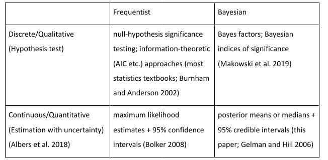

## Bayes Theorem

- If $A_i$ are *alternative events* (exactly one must happen), then:
  - $\mbox{Pr}(A_i|B) = \frac{\mbox{Pr}(B|A_i) \mbox{Pr}(A_i)}{\sum{\mbox{Pr}(B|A_j) \mbox{Pr}(A_j)}}$
  - $\mbox{Pr}(A_i)$ the *prior* probability of $A_i$
  - $\mbox{Pr}(A_i|B)$ is the *posterior* probability of $A_i$, given event $B$
- People argue about Bayesian inference, but nobody argues about Bayes theorem

## Bayesian inference

- Go from a *statistical model* of how your data are generated, to a probability model of parameter values
  - Requires *prior* distributions describing the assumed likelihood of parameters before these observations are made
  - Use Bayes theorem to go from probability of the data given parameters to the probability of parameters given data
- Once we have a posterior distribution, we can calculate a best guess for each parameter
  - Mean, median or mode
  - Only median is scale-independent

## Confidence intervals

- We do hypothesis tests using “credible intervals” – these are like confidence intervals, except that we really believe (relying on our assumptions) that there is a 95% chance that the value is in the credible interval
  - There are a lot of ways to do this. You need to decide in advance.
  - *Quantiles* are principled, but not easy in >1 dimension
  - Highest posterior density is straightforward, but scale-dependent
- Example, a linear relationship is significant if the credible interval for the slope does not include zero
- A difference between groups is significant if the credible interval for the difference does not include zero

## Advantages

- Assumptions more explicit
- Probability statements more straightforward
- Very flexible
- Can combine information from different sources

## Disadvantages

- More assumptions required
- More difficult to calculate answers
  - easy problems are easy
  - medium problems are hard
  - very hard or impossible problems are hard

# Assumptions

## Prior distributions

- Typically, start with a prior distribution that has little “information”
  - Let the data do the work
- This often means a normal (or lognormal, or gamma) with a very large variance
  - We can test for sensitivity to this choice
- Can also use a uniform distribution (on log, or linear scale) with very broad coverage

## Examples

- “Complete ignorance” can be harder to specify than you think
  - Linear vs. log scale: do we expect the probability of being between 10 and 11 grams to be the same as the prob. of being between 100 and 101 grams, or the same as the prob. of being between 100 and 110 grams??
  - Linear vs. inverse scale: if we are waiting for things to happen, do we pick our prior on the time scale (number of minutes per bus) or the rate scale (number of buses per minute)?
  - Discrete hypotheses: subdivision (nest predation example: do we consider species separately, or grouped by higher-level taxon?)

## Improper priors

- There is no uniform distribution over the real numbers
- But for Bayesian analysis, we can pretend that there is
  - This is conceptually cool, and *usually* works out fine
  - Must be able to guarantee that the *posterior* distribution exists
  - Also need to choose a scale for your uniform prior

## Statistical models

- A statistical model allows us to calculate the *likelihood* of the data based on parameters
  - Relationships between quantities, e.g.:
  - X is linearly related to Y
  - The variance of X is linearly related to Z
  - Distributions
  - X has a Poisson (or normal, or lognormal) distribution

# Making a probability model

## Assumptions

- We need enough assumptions to actually calculate the “likelihood” of our data given parameters
- To make a probability model we need prior distributions for all of the parameters we wish to estimate
- We then need to make explicit assumptions about how our data are generated, and calculate a likelihood for the data corresponding to any set of parameters

## A simple example

- for a single observation of counts
- assume the likelihood is Poisson
- assume the prior on the rate parameters is Gamma distributed
- we can write down the answer immediately (with Calc II)

# MCMC methods

## What about hard problems?

- Bayesian methods are very flexible
- We can write down reasonable priors, and likelihoods, to cover a wide variety of assumptions and situations
- Unfortunately, we usually can’t *integrate* – calculate the denominator of Bayes’ formula
- Instead we use *Markov chain Monte Carlo* methods to sample randomly from the posterior distribution
  - Simple to do, but hard to know how long you have to simulate to get a good sample of the posterior distribution

## MCMC sampling

- Rules that assure that we will visit each point in parameter space in proportion to its likelihood … eventually
- Checking convergence:
  - Look at your parameter estimates: do they seem to have settled to bouncing back and forth) rather than going somewhere?
  - Repeat the whole process with a different starting point (in parameter space): do these “chains” converge?

## Packages

- There is a lot of software, including R packages, that will do MCMC sampling for you
- We will give you examples

# Sampling from the posterior

## Great power ⇒ great responsibility

- Once you have calculated (or estimated) a Bayesian posterior, you can calculate whatever you want!
  - In particular, you can attach a probability to any combination of the parameters
  - You can simulate a model forward in time and get credible intervals not only for the parameters, but what you expect to happen